# A51800 Trend and Seasonality Analysis

Julia Bruneau

2022-07-12

### Timeseries Analysis Exploration

```r
pwater <- read_csv("forA51800_pwater.csv")
pwater$date <- as.Date(pwater$index, format = "%m/%d/%y")
pwater$week <- week(pwater$date)
pwater$month <- month(pwater$date)
pwater$year <- year(pwater$date)
```

```r
monthlyAGWS <- aggregate(pwater$AGWS, by = list(pwater$month), FUN = "mean")
colnames(monthlyAGWS) <- c("month", "AGWS")
```

## Backgroung information on time series -data:

Identifying patterns within time series can generally be through **trend analysis** and **seasonality analysis**. Trend analysis can be achieved with smoothing (moving average, distance-weighted least squared smoothing) and fitting functions (linear/nonlinear). Seasonality analysis is similar to trend, but components repeat in systematic intervals of time.

In order to work with the following packages and functions, it is important to note if our data is additive or multiplicative:  
**Additive seasonality** = the trend is linear (no changes with seasonality), **Multiplicative seasonality** = data displays seasonality and trend

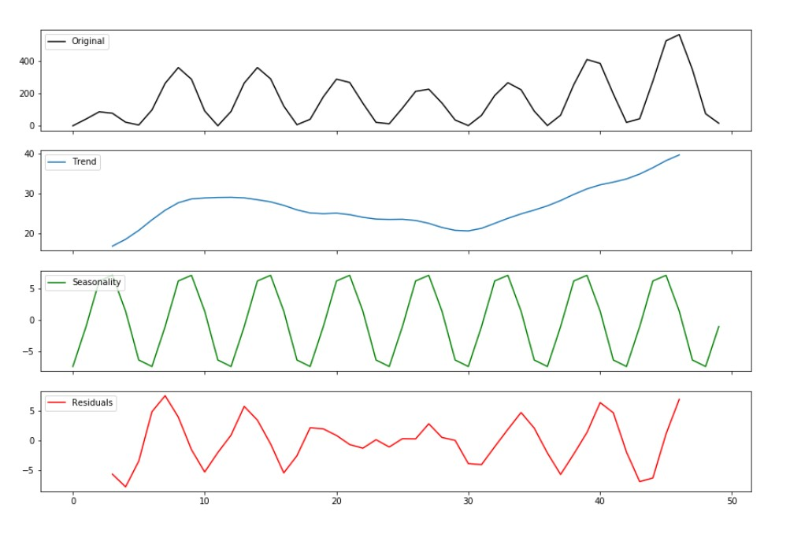

Figure 1. A graph explaining multiplicative time series data. https://dziganto.github.io/python/time%20series/Introduction-to-Time-Series/

Sources for the background information and the following demonstrations:

TTR: https://cran.r-project.org/web/packages/TTR/TTR.pdf decompose() & Holt-Winters(): https://fukamilab.github.io/BIO202/09-A-time-series.html & https://orangematter.solarwinds.com/2019/12/15/holt-winters-forecasting-simplified/#:~:text=The%20Holt%2DWinters%20method%20uses,%E2%80%9Csmooth%E2%80%9D%20a%20time%20series Timeseries & stl(): https://www.statmethods.net/advstats/timeseries.html

## TTR -package

TTR (Technical Trading Rules), is a package that has a collection of over 50 technical indicators specifically to create technical trading rules. It is questionable whether these indicators are applicable to the data we are working with, but it has nice functions to work with simple trend analysis within our data set:

**SMA** creates a simple moving average to smooth time series. Other averages are available within the package like: EMA (exponential moving average) and WMA (weighted moving average).

```
## Using libcurl 7.64.1 with Schannel
```

[figure not shown]

```r
#library(TTR)
AGWS_MA <- SMA(pwater$AGWS, n = 90) # This is the "smooth moving average" command, where the trend is set for a 90-day average.

plot(AGWS_MA, type ='l', ylab = '90-day Average AGWS (in)', xaxt = 'n', xlab = NA, col = 'blue')
axis(1, at = c(1,52596,105196,157788,210384,262980,315576), labels = c('1984','1990','1996','2002','2008','2014','2020'))
title(main = 'Active Groundwater Storage 90-day Ave')
```

# Setting a timeseries:

```r
# the functions below require data that is created with ts()
AGWS_ts <- ts(monthlyAGWS$AGWS, start = c(1984,1), end = c(2020,12), frequency = 12)
# frequency = 12 (monthly); = 4 (quarterly); = 1 (annual)
```

## Decompose() -function

The decompose(x) function estimates the trend, seasonal, and irregular components of the time series.

This function results with values: $seasonal - the seasonal component (repeated seasonal figure), $trend - the trend component, $random - the remainder part, $figure - the estimated **seasonal figure** only (with a numerical value for each month, since the time series is set for the monthly frequency), $type

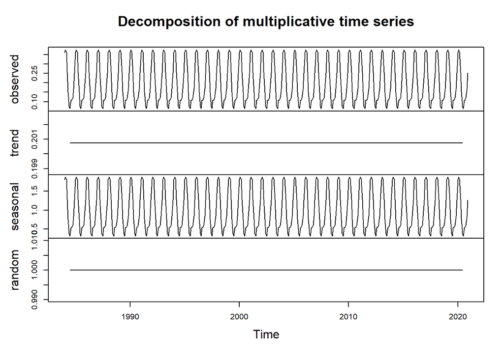

```r
agws_decomp <- decompose(AGWS_ts, type = "multiplicative") #here we note the type of data set we are working with

plot(agws_decomp)
```

```r
decomp_df <- data.frame(agws_decomp$figure)
colnames(decomp_df) <- c('Seasonality')
rownames(decomp_df) <- c('Jan','Feb','Mar','Apr','May','June','July','Aug','Sep','Oct','Nov','Dec')
decomp_df
```

```
##      Seasonality
## Jan    1.8069043
## Feb    1.8801113
## Mar    1.8195689
## Apr    1.2801528
## May    0.7532594
## June   0.3761152
## July   0.3121565
## Aug    0.5295211
## Sep    0.5444845
## Oct    0.6007182
## Nov    0.8369081
## Dec    1.2600997
```

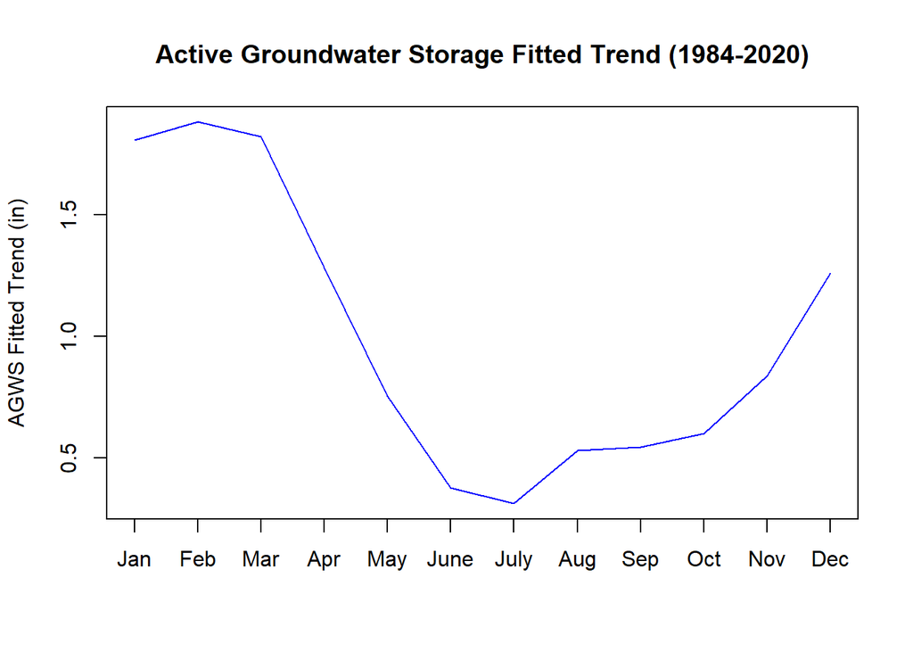

```r
plot(agws_decomp$figure, type = 'l', ylab = 'AGWS Fitted Trend (in)', xaxt = 'n', xlab = NA, col = 'blue')
axis(1, at = seq(1,12,1), labels = c('Jan','Feb','Mar','Apr','May','June','July','Aug','Sep','Oct','Nov','Dec'))
title(main = 'Active Groundwater Storage Fitted Trend (1984-2020)')
```

This could be showcased in the water year so that the plot would be a bell shape.

## Holt-Winters() -function

The Holt-Winters method uses exponential smoothing to encode lots of values from the past and use them to predict “typical” values for the present and future. The three time series behavior - value, trend, and seasonality - are expressed as three types of exponential smoothing. Simply, the function estimates the level, slope, and seasonal component at a given time point.

The values resulting from the function: $alpha - the “base value”; the higher it is, the more weight on the most recent observations, $beta - the “trend value”; higher means the trend slope is more dependent on recent trend slopes, $gamma - the “seasonal component”; higher puts more weighting on the most recent seasonal cycle (=> in a range from 0 to 1; low values carry relatively little weight regarding forecasted values), $x - the time series, $**fitted** - three columns: “xhat”, “level”, **“trend”**, $coefficients, $seasonal, $SSE - sum of squared errors, $cal

This function can be further utilized to modify the time period and to forecast future trends by using the forecast() package.

```r
agws_holt_winters <- HoltWinters(AGWS_ts, gamma = FALSE, seasonal = "multiplicative") #gamma set as false since we aren't dealing with additive data
```

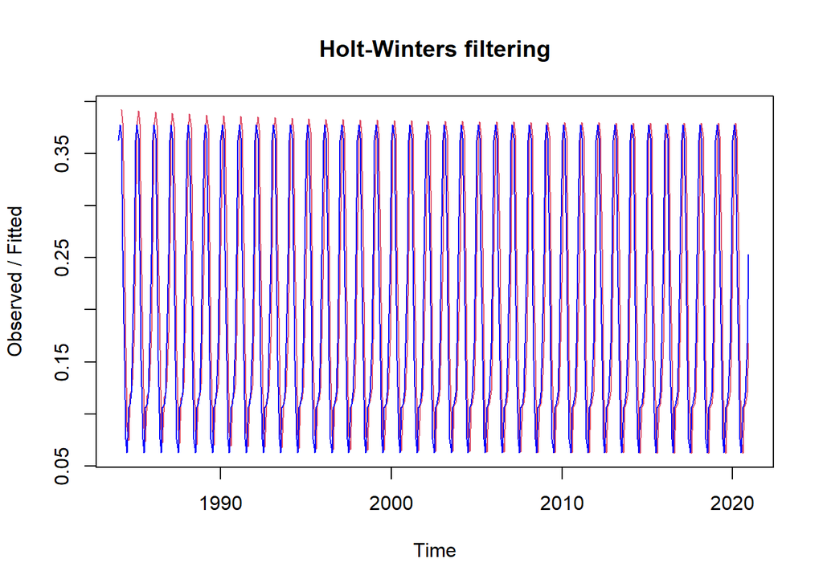

```r
plot(agws_holt_winters, col = 'blue')
```

```r
agws_ab <- data.frame(agws_holt_winters$alpha, agws_holt_winters$beta)
colnames(agws_ab) <- c('Alpha','Beta')
rownames(agws_ab) <- c('AGWS')
agws_ab
```

```
##      Alpha        Beta
## AGWS     1 0.007584582
```

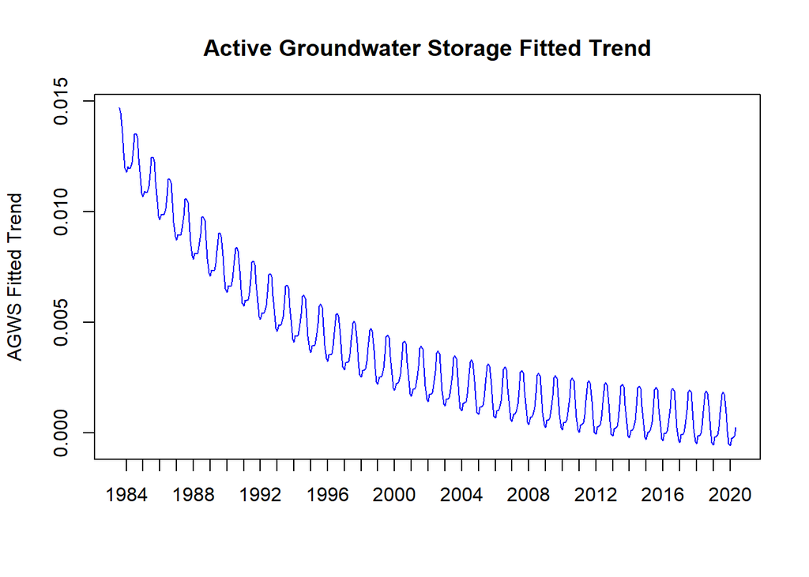

```r
# Extracting the trend -column from the fitted values:
agws_fitted <- data.frame(agws_holt_winters$fitted)
plot(agws_fitted$trend, type = 'l', ylab = 'AGWS Fitted Trend', xaxt = 'n', xlab = NA, col = 'blue')
years <- seq(1984,2020,1)
axis(1, at = seq(6,444,12), labels = years)
title(main = 'Active Groundwater Storage Fitted Trend')
```

**Conclusion:** The first plot “Holt-Winters filtering” displays the raw data and the fitted data, in order to see if the function fits well. Based on our figure it seems like it is a good fit. After extracting just the ‘trend’ column within the ‘fitted’ value, it results in a plot that demonstrates the trend within the time series where active groundwater storage decreases over the years. If gamma is set to TRUE, it doesn’t provide clean trends, this only verifies the analysis that our data is multiplicative.

## Potential futher analysis:

The function stl() was mentioned with the decompose() function. It apparently has potential for more seasonal decomposition analysis. I didn’t look into this yet.

Especially the Holt-Winter forecasting function seems to be a powerful tool for predicting future data in a time series, but it is unsure if this is necessary in our case.